# Seaborn-2Color

```python
import numpy as np
import seaborn as sns
import matplotlib.pyplot as plt
%matplotlib inline
# 设置画图大小为 (6, 6)
sns.set(rc={"figure.figsize": (6, 6)})
```

### 调色板

- 颜色很重要
- color_palette()能传入任何Matplotlib所支持的颜色
- color_palette()不写参数则默认颜色
- set_palette()设置所有图的颜色

### 分类色板

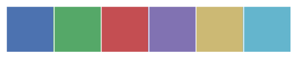

```python
current_palette = sns.color_palette()
sns.palplot(current_palette)
```

6个默认的颜色循环主题： deep, muted, pastel, bright, dark, colorblind

### 圆形画板

- 当你有六个以上的分类要区分时，最简单的方法就是在一个 **圆形的颜色空间** 中画出 **均匀间隔的颜色**(这样的色调会保持亮度和饱和度不变)。
- 这是大多数的当他们需要使用比 **当前默认颜色循环中设置的颜色更多** 时的默认方案。
- 最常用的方法是使用 hls 的颜色空间，这是RGB值的一个简单转换。

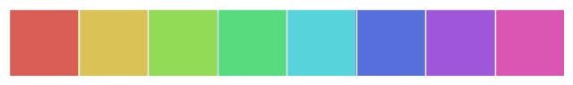

```python
sns.palplot(sns.color_palette("hls", 8))
```

### 使用color_palette("hls", 8)

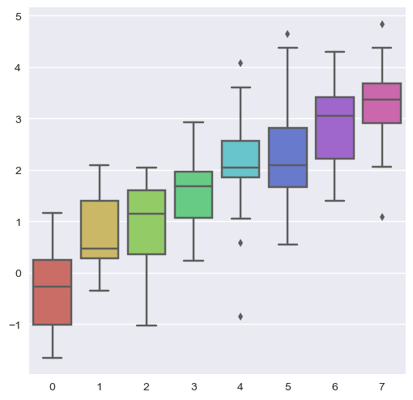

```python
data = np.random.normal(size=(20, 8)) + np.arange(8) / 2
# 使用palette
sns.boxplot(data=data, palette=sns.color_palette("hls", 8))
```

hls_palette()函数来控制颜色的亮度和饱和

- l-亮度 lightness
- s-饱和 saturation

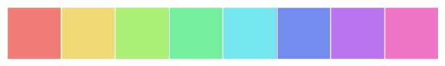

```python
sns.palplot(sns.hls_palette(8, l= .7, s = .8))
```

### 调出来的颜色是成对存在的 color_palette("Paired", 8)

- 如同一个国家的两个运动员

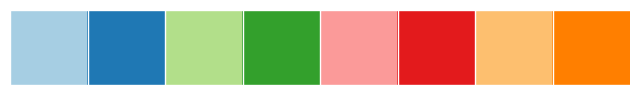

```python
sns.palplot(sns.color_palette("Paired", 8))
```

### 调色板颜色设置

- #### 使用xkcd颜色来命名颜色 ### xkcd包含了一套众包努力的针对随机RGB色的命名。产生了954个可以随时通过xdcd_rgb字典中调用的命名颜色。

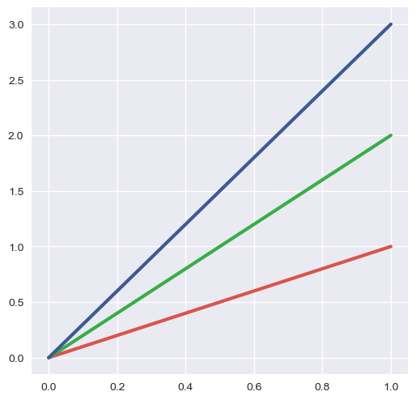

```python
plt.plot([0, 1], [0, 1], sns.xkcd_rgb["pale red"], lw=3)
plt.plot([0, 1], [0, 2], sns.xkcd_rgb["medium green"], lw=3)
plt.plot([0, 1], [0, 3], sns.xkcd_rgb["denim blue"], lw=3)
```

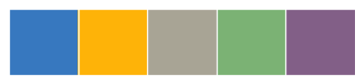

```python
colors = ["windows blue", "amber", "greyish", "faded green", "dusty purple"]
sns.palplot(sns.xkcd_palette(colors))

# 稍微总结一下
# sns.palplot(sns.color_palette())
# sns.palplot(sns.color_palette("hls", 8))
# sns.palplot(sns.color_palette("Paired", 8))
# sns.palplot(sns.hls_palette(8, l= .7, s = .8))
```

### 连续色板

色彩随数据变换，比如数据越来越重要则颜色越来越深

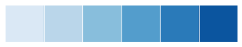

```python
sns.palplot(sns.color_palette("Blues"))
```

如果想要翻转渐变，可以在面板名称中添加一个_r后缀

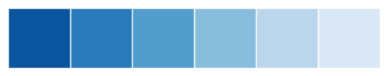

```python
# sns.palplot(sns.color_palette("BuGn_r"))
sns.palplot(sns.color_palette("Blues_r"))
```

### cubehelix_palette()调色板

色调线性变换

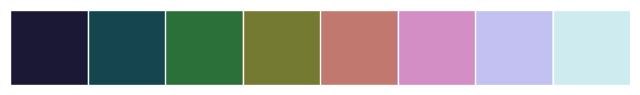

```python
# 亮度和饱和度都 线性变换
sns.palplot(sns.color_palette("cubehelix", 8))
```

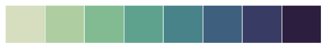

```python
sns.palplot(sns.cubehelix_palette(8, start=.5, rot=-.75))
```

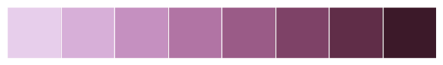

```python
sns.palplot(sns.cubehelix_palette(8, start=.75, rot=-.150))
```

### light_palette() 和dark_palette()调用定制连续调色板

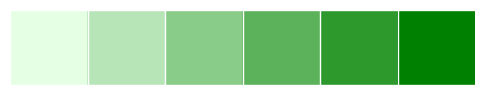

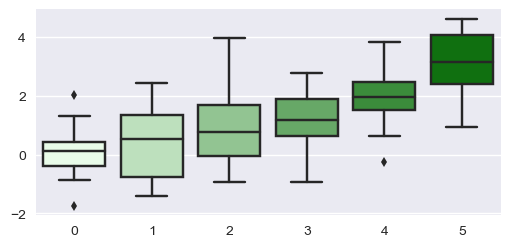

```python
sns.palplot(sns.light_palette("green"))

fig = plt.figure()
ax1 = fig.add_subplot(2,1,2)
# 应用
data = np.random.normal(size=(20, 6)) + np.arange(6) / 2
# 使用palette
sns.boxplot(data=data, palette=sns.color_palette(sns.light_palette("green")))
```

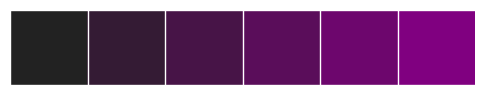

```python
sns.palplot(sns.dark_palette("purple"))
```

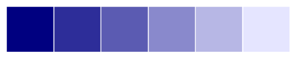

```python
sns.palplot(sns.light_palette("navy", reverse=True))
```

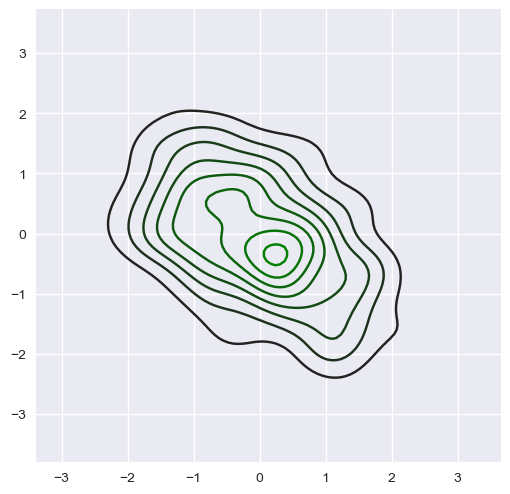

```python
x, y = np.random.multivariate_normal([0, 0], [[1, -.5], [-.5, 1]], size=300).T
pal = sns.dark_palette("green", as_cmap=True)
sns.kdeplot(x, y, cmap=pal)
```

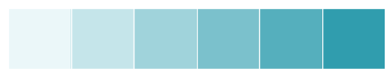

```python
sns.palplot(sns.light_palette((210, 90, 60), input="husl"))
```